# Probability Sampling

Corinne Riddell

September 14, 2022

# Learning objectives

- Learn how to take a random sample (a.k.a. a probability sample) in R
- Know the difference between a simple random sample, a proportionate stratified sample, a disproportionate stratified sample, and a multistage sample
- Know how to take a simple random sample and a proportionate stratified sample in R
- Introduce the idea of probability
- See how an estimate of probability is related to the size of the sample chosen from the underlying population

# Recall from last class

- Last class we discussed non-probability studies (e.g., convenience samples) and how they are not necessarily representative of an underlying population from which they were sampled.
- To obtain a more representative sample, we can take a **probability sample**. The most common type of probability sample is a **simple random sample**

# Simple random sample (SRS)

- Simple random sample (SRS): A sample chosen by chance, where each individual in the data set has the same chance of being selected.
- We can easily choose a SRS from a data frame in R

# Example of SRS in R

- First read in the hospital cesarean data

```r
CS_data <- read_xlsx("./data/kozhimannil.xlsx", sheet = 1)
CS_data <- CS_data %>% mutate(ID = row_number())
head(CS_data)
```

```
## # A tibble: 6 × 8
##   Births HOSP_BEDSIZE cesarean_rate lowrisk_cesarean_rate ...5  `Cesarean rate…`
##    <dbl>        <dbl>         <dbl>                 <dbl> <lgl>            <dbl>
## 1    767            1         0.344                0.107  NA                34.4
## 2    183            1         0.454                0.186  NA                45.4
## 3    668            1         0.430                0.195  NA                43.0
## 4    154            1         0.279                0.0844 NA                27.9
## 5    327            1         0.306                0.119  NA                30.6
## 6   2356            1         0.301                0.0662 NA                30.1
## # … with 2 more variables: `Low Risk Cearean rate*100` <dbl>, ID <int>
```

# Example of SRS in R

In the following code chunk, we use `slice_sample(n = 100)` to take a SRS of 100 individuals (here, hospitals) from `CS_data`.

```r
CS_100_1 <- CS_data %>% slice_sample(n=100)
```

Suppose we took a second sample…

```r
CS_100_2 <- CS_data %>% slice_sample(n=100)
```

Do you expect `head(CS_100_1)` to equal `head(CS_100_2)`?

# Example of SRS in R

```r
head(CS_100_1 %>% select(Births, HOSP_BEDSIZE, cesarean_rate, ID))
```

```
## # A tibble: 6 × 4
##   Births HOSP_BEDSIZE cesarean_rate    ID
##    <dbl>        <dbl>         <dbl> <int>
## 1    185            2         0.357   178
## 2    697            1         0.363    94
## 3   7552            3         0.284   333
## 4    514            1         0.539    17
## 5    401            2         0.411   162
## 6   1132            2         0.205   266
```

# Example of SRS in R

```r
head(CS_100_2 %>% select(Births, HOSP_BEDSIZE, cesarean_rate, ID))
```

```
## # A tibble: 6 × 4
##   Births HOSP_BEDSIZE cesarean_rate    ID
##    <dbl>        <dbl>         <dbl> <int>
## 1    617            1         0.365    14
## 2    105            1         0.267    21
## 3    767            1         0.344     1
## 4    100            1         0.37     39
## 5    163            2         0.393   244
## 6    294            2         0.364   169
```

# Example of SRS in R

```r
identical(CS_100_1, CS_100_2)
```

```
## [1] FALSE
```

# Example of SRS in R

**Question:** Why are these first six lines different, when the `slice_sample(n=100)` code is the same? So far with the functions we’ve learned in class, if we wrote the same line of code, we would generate the same result. What is going on?

**Answer:** Anytime you do something *randomly* in R, the results will be different. This is a good thing! This allows you to pick many different random samples. In future weeks we will do this a lot.

# Example of SRS in R

What if you want to ensure that you pick the same SRS as a friend?

Then you need to use `set.seed()`. Here we set the seed to `123` before running the sampling code. This ensures that the random samples generated are the same. Try to run this code again with a number other than `123`:

```r
set.seed(123)
CS_100_1 <- CS_data %>% slice_sample(n=100)

set.seed(123)
CS_100_2 <- CS_data %>% slice_sample(n=100)

identical(CS_100_1, CS_100_2)
```

```
## [1] TRUE
```

# SRS a fraction in R

Another way to take a random sample is to specify the fraction of the dataset that you’d like to include in your sample using `slice_sample(prop = 0.05)`. Here, we sample 5% of the individuals (here, hospitals):

```r
CS_5percent <- CS_data %>% slice_sample(prop = 0.05)
```

# Proportionate Stratified sampling in R

Suppose you want to take a 10% sample of individuals within each county in California. This is called a proportionate stratified sample. To do this you would use the following code: `CA_data %>% group_by(county) %>% slice_sample(prop = 0.1)`

Here is an example using the `CS_data`:

```r
CS_10percent_grouped <- CS_data %>%
  group_by(HOSP_BEDSIZE) %>%
  slice_sample(prop = 0.1)

dim(CS_10percent_grouped)
```

```
## [1] 57  8
```

In this example, proportionate stratified SRS assembles a sample that maintains the relative proportions of `HOSP_BEDSIZE` in the chosen sample compared to the population

# Proportionate Stratified sampling in R

How to check you really did sample 10% of each `HOSP_BEDSIZE` group?

First see how many hospitals fall into each category in the original data

```r
CS_data %>% group_by(HOSP_BEDSIZE) %>% tally()
```

```
## # A tibble: 3 × 2
##   HOSP_BEDSIZE     n
##          <dbl> <int>
## 1            1   131
## 2            2   179
## 3            3   270
```

Then in the sample:

```r
CS_10percent_grouped%>%group_by(HOSP_BEDSIZE) %>% tally()
```

```
## # A tibble: 3 × 2
##   HOSP_BEDSIZE     n
##          <dbl> <int>
## 1            1    13
## 2            2    17
## 3            3    27
```

# Disproportionate Stratified sampling in R

- When might you want to over represent certain groups?
- Example: Estimating infant mortality by race/ethnicity when some race/ethnic groups are very small (e.g., indigenous groups in U.S./Canada)
- Then, you may want to over sample certain groups so you can better estimate infant mortality in those groups than if you sampled proportionately
- In this case, you could filter your sample into different race/ethnic groups and take samples of different sizes (or fractions) from each group. You won’t be asked how to do this in R, but rather, know what a disproportionate stratified sample is and why you might want to take this kind of sample.

# Multistage sampling

- **Multistage sampling** occurs when you first sample a clustering unit and then within the clustering unit select individuals.
- Examples of **clustering units** include hospitals, schools, counties, etc.
- For example, sampling schools using a SRS, and then sampling students within those schools.
- Think about the differences between taking a multistage sample of students within schools vs. a SRS of students across a set of schools. How would these samples look different. Suppose you are taking measurements from blood tests from the students, which sample is more practical to conduct? Which one allows you to estimate some quantities for the sampled schools?

# Applied example: Using a sample to estimate low birthweight in U.S. territories

# Description of the data

These data are births by place of occurrence for U.S. territories (American Samoa, Guam, N. Mariana Islands, Puerto Rico, and US Virgin Islands) from the year 2015.

This is a subset of the data downloaded from [here](http://www.nber.org/data/vital-statistics-natality-data.html). You can find more information about the data set here.

# Data dictionary

Here is the data dictionary for this dataset:

| Variable | Description |
| --- | --- |
| babyID | Unique identifier: row number |
| dbwt | Birth weight in Grams: 227-8165 grams |
| combgest | Combined gestation, in weeks: 17th to 47th week of gestation |
| sex | Assigned sex at birth: M (Male) or F (Female) |
| dob_mm | Birth month |
| cig_rec | If the mother reports smoking in any of the three trimesters of pregnancy she is classified as a smoker: (Y) Yes, (N) No, or (U) Unknown |

# Import the data into R

```r
library(tidyverse)
birth_data <- read_csv(file = "./data/L03_US-territories-births.csv")
birth_data <- birth_data%>% select(-...1)
```

```r
head(birth_data)
```

```
## # A tibble: 6 × 6
##   babyID  dbwt combgest sex   dob_mm cig_rec
##    <dbl> <dbl>    <dbl> <chr>  <dbl> <chr>
## 1      1  2977       37 M          1 N
## 2      2  3191       41 M          1 Y
## 3      3  1786       32 F          1 N
## 4      4  4489       39 M          1 N
## 5      5  3203       38 M          1 N
## 6      6  3203       39 F          1 N
```

# Overview of the applied example

- Take a **simple random sample** from the **population** of births. We will use this sample to **estimate** the proportion of babies who have low birthweight in the population.
- To know how close our **estimate** is to the **true value**, we will first calculate the **true** probability of an infant being born less that 5 lbs 8 ounces, or 2500 grams, which is the traditional cutoff used to classify an infant as low birthweight.
- In real life settings, we would not know the **true** probability, we would only know the value we estimate from our sample. But here, we can investigate how close the sample estimate is to the true parameter and see what we can do to make our estimate even better.
- We will see how well we can estimate the true probability based on random samples of varying sizes.

# Step 1: Add a variable to the dataset for low birthweight (LBW)

```r
birth_data <- birth_data %>% mutate(lbw = dbwt < 2500)
```

- What does the variable `lbw` store?
- `lbw` stores “logical” values, which means it is either equal to `TRUE` or `FALSE`
- Variables that store only two values are called **binary** variables. They are most commonly stored as logical data (TRUE/FALSE), numeric (0/1) or categorical (“Yes”/“No”).
- In the above code, R evaluates whether birthweight (`dbwt`) is less than 2500 grams for each birth. If it is, then `lbw = TRUE` for that birth, and if not then `lbw = FALSE` for that birth.

# Step 2: Calculate the proportion of low birthweight infants in overall

population of the US territories

```r
lbw_population <- birth_data %>% summarize(true_prob_lbw = mean(lbw))
lbw_population
```

```
## # A tibble: 1 × 1
##   true_prob_lbw
##           <dbl>
## 1         0.102
```

- Question: How did we take a mean of values equal to `TRUE` or `FALSE`?
- Answer: R treats `TRUE` as equivalent to `1` and `FALSE` as equivalent to `0`. The mean of a variable coded as 0 or 1 is the **proportion** of individuals who have low birthweight.
- Remember: we do not usually know the true value because we rarely have data on every individual in a population.

# Step 3: Take a random sample of size n=10

```r
random_sample_n10 <- birth_data %>%
  slice_sample(n = 10) %>%
  mutate(sample_size = n())
#the last line of code adds the sample size to every row of the new data frame
#we will want to reference this information later
```

# Step 4: Progressively increase the sample size and store those samples

Sample the rows of data using the following sample sizes. Assign your samples each to a different R object.

```
1. 10
2. 50
3. 100
4. 200
5. 500
6. 1000
7. 5000
8. 10000
9. 36724 (i.e, the entire target population)
```

# Step 4 code

```r
random_sample_n50 <- birth_data %>%   slice_sample(n = 50) %>% mutate(sample_size = n())

random_sample_n100 <- birth_data %>% slice_sample(n = 100) %>% mutate(sample_size = n())

random_sample_n200 <- birth_data %>% slice_sample(n = 200) %>% mutate(sample_size = n())

random_sample_n500 <- birth_data %>% slice_sample(n = 500) %>% mutate(sample_size = n())

random_sample_n1000 <- birth_data %>% slice_sample(n = 1000) %>% mutate(sample_size = n())

random_sample_n5000 <- birth_data %>% slice_sample(n = 5000) %>% mutate(sample_size = n())

random_sample_n10000 <- birth_data %>% slice_sample(n = 10000) %>% mutate(sample_size = n())

whole_pop <- birth_data %>% slice_sample(n = nrow(birth_data)) %>% mutate(sample_size = n())
```

# Step 4 side note

By default `slice_sample(n=100)` takes a sample of size 100 **without replacement** This means, that each individual can only be included in the sample at most once.

In future classes, we will introduce methods where we select a sample **with replacement**. We will talk more about how this works in the coming weeks.

# Step 5: calculate the estimate of the proportion of LBW for each random sample

# Step 5: code to estimate the proportions more efficiently

The function `bind_rows(df1, df2, df3, ...)` can be used to stack multiple data frames (e.g. df1, df2, df3, …) on top of wach other when they have each contain the same variables. Bind together the 9 data frames created in the previous code chunk using `bind_rows()`and assign the stacked data frame the name `stacked_samples`:

```r
stacked_samples <- bind_rows(random_sample_n10, random_sample_n50,
                             random_sample_n100, random_sample_n200,
                             random_sample_n500, random_sample_n1000,
                             random_sample_n5000, random_sample_n10000,
                             whole_pop)
```

# Step 5: code to estimate the proportions more efficiently

Estimate the proportion of babies with low birthweight using each of your samples in `stacked_samples`. Hint: `group_by()` and `summarize()` will come in handy! Assign the output to a data frame called `sample_estimates`

```r
sample_estimates <- stacked_samples %>%
  group_by(sample_size) %>%
  summarize(estimated_proportion_lbw = mean(lbw))

sample_estimates
```

```
## # A tibble: 9 × 2
##   sample_size estimated_proportion_lbw
##         <int>                    <dbl>
## 1          10                    0.1
## 2          50                    0.22
## 3         100                    0.12
## 4         200                    0.115
## 5         500                    0.106
## 6        1000                    0.091
## 7        5000                    0.098
## 8       10000                    0.103
## 9       36724                    0.102
```

# Step 6: Visualize the results

- Make a line plot of the estimates of the probabilities versus the sample size.
- Add a horizontal line to the line plot at the true value that you are striving to estimate.
- You might also want to add points on top of the line to see exactly where the estimates are.

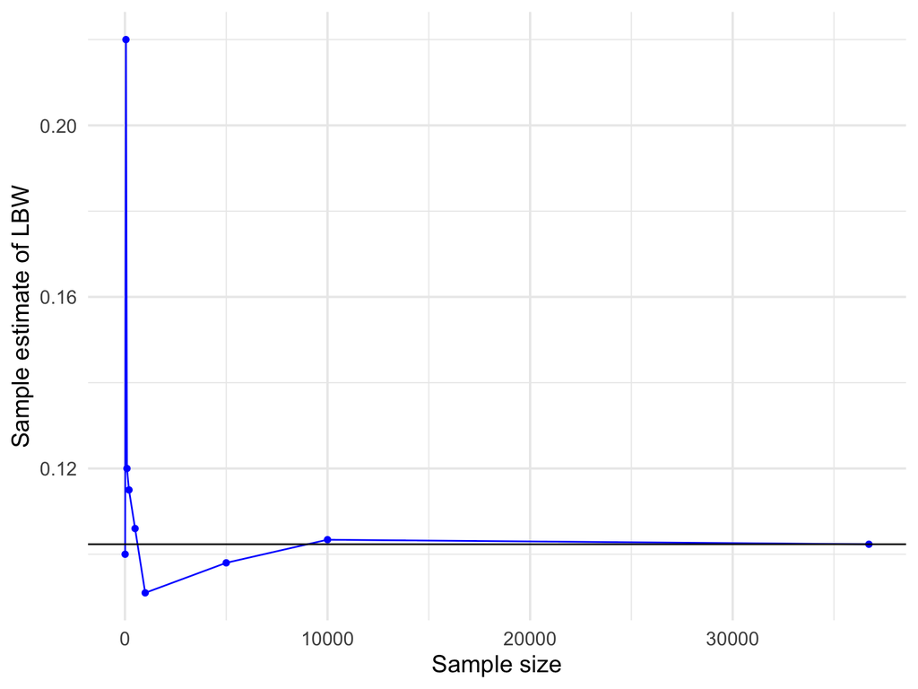

```r
ggplot(sample_estimates, aes(x = sample_size, y = estimated_proportion_lbw)) +
  geom_line(col = "blue") +
  geom_point(col = "blue") +
  geom_hline(yintercept = lbw_population %>% pull(true_prob_lbw)) +
  labs(y = "Sample estimate of LBW", x = "Sample size") +
  theme_minimal(base_size = 15)
```

# Step 6: Visualize the results

- Because the scale of the x axis is so large, try using `scale_x_log10()` to convert the x scale to a logarithm.

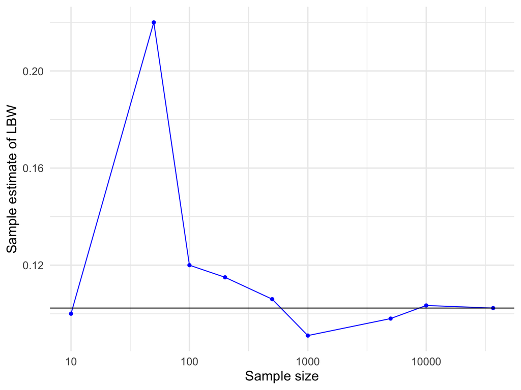

```r
ggplot(sample_estimates, aes(x = sample_size, y = estimated_proportion_lbw)) +
  geom_line(col = "blue") +
  geom_point(col = "blue") +
  geom_hline(yintercept = lbw_population %>% pull(true_prob_lbw)) +
  scale_x_log10() +
  labs(y = "Sample estimate of LBW", x = "Sample size") +
  theme_minimal(base_size = 15)
```

# Check your understanding!

1. What happens as sample size increases?
2. Will it **always** be the case that a higher sample size produces an estimate closer to the true value than a lower sample size?